# Week 8

Hao Ye with modifications from Lynn Waterhouse

March 02, 2017

# 1 Objectives

- 3d plotting using `rgl`
  - basic plots with points and lines
  - setting plotting parameters
  - surface plots
  - output to file
  - R markdown hooks

# 2 3D plotting

The `rgl` package allows us to produce interactive 3-d plots. The basic commands are similar to the plotting functions in base R. The package was developed by Daniel Adler (University of Gottingen) and Duncan Murdoch (University of Western Ontario).

Using `rgl` package you can make the following: -solid 3D objects -embed 2D objects and surfaces in 3D space -perform real-time rotation and zooming -embed functions just like 2D graphs -modify, color, text, shading just like 2D graphs

## 2.1 Basic plots

The default plot3d uses points. Input is given as x, y, z coordinates as separate vectors, or as columns to a matrix or data.frame.

By using rgl, one can rotate the 3d-plot. This is helpful sometimes when you want to rotate the 3D shape to make a point. It can also be not-so-helpful when you want to show someone something from a specific angle. Thankfully you can reproduce the starting point (more on that later).

Many tutorials suggest that you open the rgl device first. They warn that you may receive an error otherwise. After this you should see a new window pop up. This is the rgl device, and the objects we make will go in here.

```r
library(rgl)
library(viridis)
open3d()
```

```
## wgl
##   1
```

We can open a window of a specific size and location.

```r
# open3d(windowRect = c(x, y, width, height) )
# Example
open3d(windowRect = c(00,00, 100, 576) )
```

```
## wgl
##   2
```

Let's make some data and plot it out.

```r
open3d()
```

```
## wgl
##   3
```

```r
n <- 1000
x <- sort(rnorm(n))
y <- rnorm(n)
z <- rnorm(n) + atan2(x, y)
plot3d(x, y, z, col = viridis(n))
```

## 2.2 Zoom and Rotation

One of the advantages of `rgl` is that it allows us to rotate and zoom on the object in the rgl device. You can do this manually. To rotate you hold down on the mouse or touchpad and move, to zoom use the scroll wheel on a mouse or press ctrl+touchpad for PC or 2 finger up/down on a Mac. To zoom and rotate with the PC (note theta nad phi are in spherical coordinates not radians):

```r
rgl.viewpoint( theta = 0, phi = 15, fov = 60, zoom = 1, scale = par3d("scale"),
               interactive = TRUE)
```

Try playing with the zoom. Note that as zoom gets bigger, you zoom out, and as zoom gets smaller (closer to 0) it zooms in. Instead of using theta and phi one can set the user point of view using `userMatrix`.

## 2.3 Changing Plot Type

Changing the plot type to `s` draws spheres instead of flat points.

```r
plot3d(x, y, z, type = "s", col = viridis(n), size = 1)
```

Changing the plot type to `l` draws connected lines.

```r
f <- function(x) {c(10 * (x[2] - x[1]),
                    x[1] * (28 - x[3]) - x[2],
                    x[1] * x[2] - 8/3 * x[3])}

points <- matrix(20, nrow = n, ncol = 3)
dt <- 0.01
for(t in 2:NROW(points))
{
    xx <- points[t-1,]
    k1 <- f(xx)
    k2 <- f(xx + dt/2 * k1)
    k3 <- f(xx + dt/2 * k2)
    k3 <- f(xx + dt/2 * k3)
    k4 <- f(xx + dt * k3)
    points[t,] <- xx + dt/6 * (k1 + 2*k2 + 2*k3 + k4)
}

dist_1 <- sqrt(rowSums((points - matrix(c(6*sqrt(2), 6*sqrt(2), 27),
                                     nrow = n, ncol = 3, byrow = TRUE))^2))
dist_2 <- sqrt(rowSums((points - matrix(c(-6*sqrt(2), -6*sqrt(2), 27),
                                     nrow = n, ncol = 3, byrow = TRUE))^2))
min_dist <- pmin(dist_1, dist_2)

plot3d(points, type = "l", col = hsv(h = (min_dist - min(min_dist)) / (max(min_dist) - min(min_dist)), s = 1, v = 1))
```

## 2.4 Adding points and lines to a plot

Note that points and lines can be added to an existing plot using the `points3d` and `lines3d` functions respectively.

```r
x <- sort(rnorm(n))
y <- rnorm(n)
z <- rnorm(n)
plot3d(x, y, z, col = viridis(n), size = 2)

theta <- seq(0, 4*pi, length.out = n)
phi <- seq(0, 2*pi, length.out = n)
lines3d(cos(seq(0, 4*pi, length.out = n)),
        sin(seq(0, 8*pi, length.out = n)),
        cos(seq(0, 6*pi, length.out = n)), lwd = 5)

points3d(mean(x), mean(y), mean(z), size = 10)
```

## 2.5 Plot parameters

To make plots reproducible, it's useful to be able to recreate specific plot settings, e.g. after resizing, rotating the interactive plot. `par3d` is the function that both sets and gets plot parameters. I found that the important ones are FOV, scale, zoom, viewport, windowRect, userMatrix, and projMatrix. Note that userMatrix and projMatrix duplicate what some of the other values do.

```r
plot3d(points, type = "l", col = hsv(h = (min_dist - min(min_dist)) / (max(min_dist) - min(min_dist)),
                                     s = 1, v = 1))

par3d()
```

```
## $antialias
## [1] 8
##
## $FOV
## [1] 60
##
## $ignoreExtent
## [1] FALSE
##
## $listeners
## [1] 13
##
## $mouseMode
##        left       right      middle       wheel
## "trackball"      "zoom"       "fov"      "pull"
##
## $observer
## [1]  0.00000  0.00000 83.45316
##
## $modelMatrix
##          [,1]      [,2]       [,3]        [,4]
## [1,] 1.032555 0.0000000  0.0000000   -1.933885
## [2,] 0.000000 0.8512856 -0.2940757    7.632606
## [3,] 0.000000 0.2281013  1.0975053 -112.150284
## [4,] 0.000000 0.0000000  0.0000000    1.000000
##
## $projMatrix
##          [,1]     [,2] [,3]      [,4]
## [1,] 1.732051 0.000000    0    0.0000
## [2,] 0.000000 1.732051    0    0.0000
## [3,] 0.000000 0.000000   -2 -125.1797
## [4,] 0.000000 0.000000   -1    0.0000
##
## $skipRedraw
## [1] FALSE
##
## $userMatrix
##      [,1]      [,2]       [,3] [,4]
## [1,]    1 0.0000000  0.0000000    0
## [2,]    0 0.9659258 -0.2588190    0
```

[output cut: 24 more lines]

```
##
## $cex
## [1] 1
##
## $useFreeType
## [1] FALSE
##
## $fontname
## [1] "TT Arial"
##
## $maxClipPlanes
## [1] 8
##
## $glVersion
## [1] 4.3
```

```r
a<-par3d()

rgl.viewpoint( userMatrix=a$userMatrix, fov = 60, zoom = 1, scale = par3d("scale"),
               interactive = TRUE)
```

```r
userMatrix <- matrix(c(0.8016672, 0.5976394, -0.01252565, 0,
                       -0.1470179, 0.2174320, 0.96493983, 0,
                       0.5794096, -0.7717192, 0.26217180, 0,
                       0.0000000, 0.0000000, 0.00000000, 1),
                     byrow = TRUE, nrow = 4)
zoom <- 1
windowRect <- c(2, 44, 944, 878)
scale <- c(1.0325553, 0.8813157, 1.1362212)
FOV <- 30
observer <- matrix(c(0, 0, 160), ncol = 3)
par3d(userMatrix = userMatrix,
      zoom = zoom,
      FOV = FOV,
      scale = scale,
      windowRect = windowRect)
observer3d(observer)
```

## 2.6 Changing plot settings

Note that we can also control the display of axes and bounding boxes:

```r
plot3d(points, type = "l", col = hsv(h = (min_dist - min(min_dist)) / (max(min_dist) - min(min_dist)), s = 1, v = 1),
       axes = FALSE,
       xlab = "", ylab = "", zlab = "")
axes3d(c("x--", "y+-", "z--"))
mtext3d("y", "y+-", line = 2)
```

## 2.7 Surface Plots

```r
data(volcano)
open3d()
```

```
## wgl
##   4
```

```r
z <- 2 * volcano        # Exaggerate the relief
x <- 10 * (1:nrow(z))   # 10 meter spacing (S to N)
y <- 10 * (1:ncol(z))   # 10 meter spacing (E to W)

zlim <- range(y)
zlen <- zlim[2] - zlim[1] + 1

colorlut <- terrain.colors(zlen) # height color lookup table

col <- colorlut[ z - zlim[1] + 1 ] # assign colors to heights for each point

surface3d(x, y, z, color = col, back = "lines")
```

## 2.8 Saving output to a file

An existing plot can be saved to a file using the `rgl.postscript` function, which can export several different formats

```r
plot3d(points, type = "l", col = hsv(h = (min_dist - min(min_dist)) / (max(min_dist) - min(min_dist)), s = 1, v = 1))

rgl.postscript("lorenz.pdf", fmt = "pdf")
```

## 2.9 R markdown hooks

`rgl` plots are created in a separate window, which means that they don't normally show up in knitted output from R markdown. However, the `knitr` package contains hooks to embed `rgl` plots, either in static form (`hook_rgl`) or as an interactive webgl figure (`hook_webgl`).

```r
library(knitr)
knit_hooks$set(rgl = hook_rgl)
knit_hooks$set(webgl = hook_webgl)
```

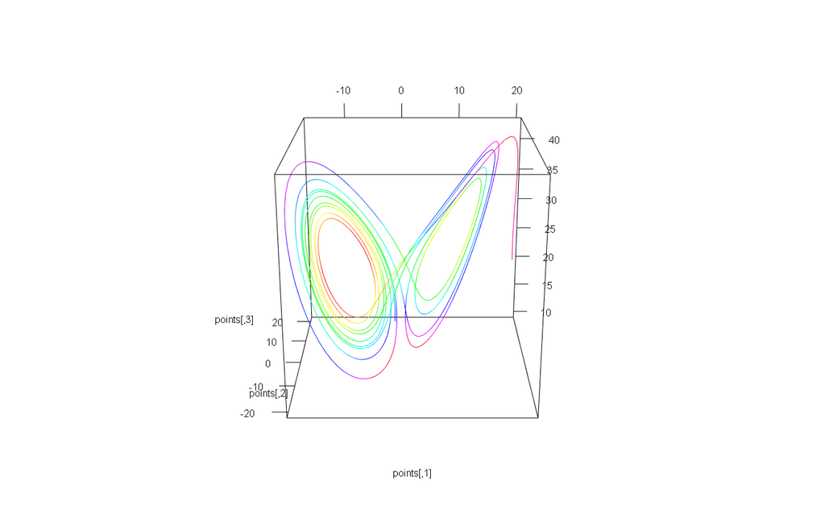

```r
plot3d(points, type = "l", col = hsv(h = (min_dist - min(min_dist)) / (max(min_dist) - min(min_dist)), s = 1, v = 1))
```

```r
plot3d(points, type = "l", col = hsv(h = (min_dist - min(min_dist)) / (max(min_dist) - min(min_dist)), s = 1, v = 1))
```

[interactive chart not shown]

# 3 Resources

[1] http://scs.math.yorku.ca/index.php/MATH_6627_2012-13_Practicum_in_Statistical_Consulting/R_tutorials/rgl_tutorial

[2] http://www.sthda.com/english/wiki/a-complete-guide-to-3d-visualization-device-system-in-r-r-software-and-data-visualization#setup-the-environment

[3] https://www.r-bloggers.com/creating-3d-geographical-plots-in-r-using-rgl/

[4] https://cran.r-project.org/web/packages/rgl/vignettes/rgl.html

[5] http://brazenly.blogspot.com/2016/08/r-graphics-tutorial-series-part-3.html

# 4 A package that builds upon rgl- Ocean View

Learn more: https://cran.r-project.org/web/packages/OceanView/vignettes/OceanView.pdf

Additional links: http://www.rforscience.com/rpackages/visualisation/oceanview/